# GDC Biospecimen Report

GDC Data are downloaded from the GDC data portal on 7/25/2021.

## Analytes

#### **analyte_type**

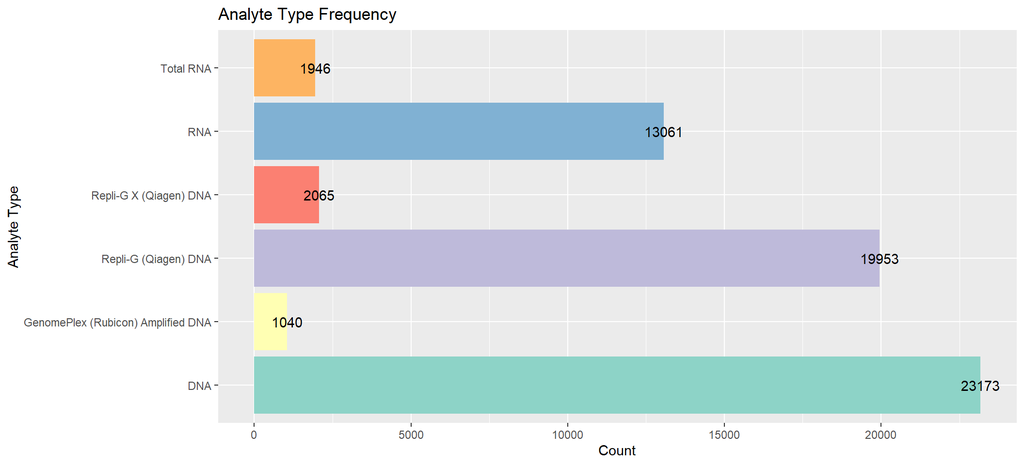

There were 11292 NA entries.

##### Unused Values:

- cfDNA
- EBV Immortalized Normal
- FFPE DNA
- FFPE RNA
- Nuclei RNA
- Repli-G Pooled (Qiagen) DNA

12 Total Values, 6 Unused

#### **analyte_type_id**

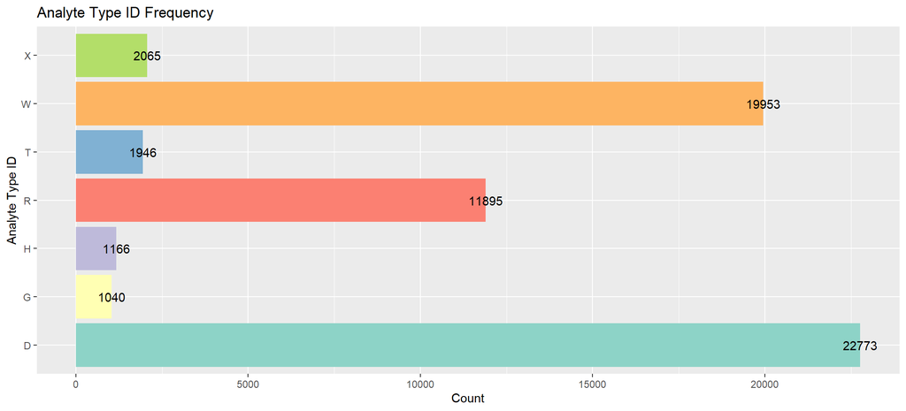

##### Unused Values:

10 Total Values, 3 Unused

- E
- S
- Y

#### **Correlation between the two set of values**

Table 1.3: Correlation Between Analyte Type and Analyte Type ID

| Analyte Type ID | Analyte Type | Frequency |
| --- | --- | --- |
| ’– | DNA | 400 |
| D | DNA | 22773 |
| G | GenomePlex (Rubicon) Amplified DNA | 1040 |
| W | Repli-G (Qiagen) DNA | 19953 |
| X | Repli-G X (Qiagen) DNA | 2065 |
| H | RNA | 1166 |
| R | RNA | 11895 |
| T | Total RNA | 1946 |

##### **Field values without 1:1 Correspondence:**

Table 1.4: Field Values between Analyte Type and Type ID without 1:1 correspondence

| Analyte Type ID | Analyte Type | Frequency |
| --- | --- | --- |
| ’– | DNA | 400 |
| D | DNA | 22773 |
| H | RNA | 1166 |
| R | RNA | 11895 |

#### **normal_tumor_genotype_snp_match**

Table 1.5: Normal Tumor Genotype Match Value Distribution

| Match | Frequency |
| --- | --- |
| NA | 69195 |
| Yes | 3335 |

## Aliquots

#### **analyte_type**

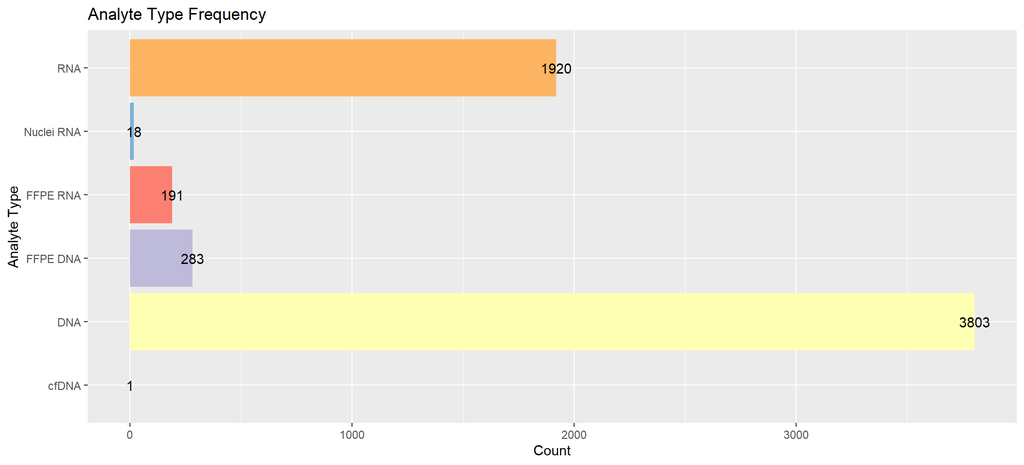

There were 152085 NA entries.

##### Unused Values:

- EBV Immortalized Normal
- GenomePlex (Rubicon) Amplified DNA
- Repli_G (Qiagen) DNA
- Repli-G Pooled (Qiagen) DNA
- Repli-G X (Qiagen) DNA
- Total RNA

12 total field values, 6 unused.

#### **analyte_type_id**

There were 152085 NA entries.

##### Unused Values:

- E
- G
- H
- S
- T
- W
- X
- Y

10 total field values, 8 unused.

#### **Correlation between analyte_type and analyte_type_id values in aliquots**

Table 2.2a: Correlation between Aliquot Analyte Type and Analyte Type ID

| Analyte Type ID | Analyte Type | Frequency |
| --- | --- | --- |
| ’– | cfDNA | 1 |
| ’– | DNA | 3654 |
| D | DNA | 149 |
| ’– | FFPE DNA | 283 |
| ’– | FFPE RNA | 191 |
| ’– | Nuclei RNA | 18 |
| ’– | RNA | 1870 |
| R | RNA | 50 |

##### **Field values without 1:1 Correspondence:**

Table 2.2b: Field Values between Aliquot Analyte Type and Type ID without 1:1 correspondence

| Analyte Type ID | Analyte Type | Frequency |
| --- | --- | --- |
| ’– | cfDNA | 1 |
| ’– | DNA | 3654 |
| D | DNA | 149 |
| ’– | FFPE DNA | 283 |
| ’– | FFPE RNA | 191 |
| ’– | Nuclei RNA | 18 |
| ’– | RNA | 1870 |
| R | RNA | 50 |

## Sample

#### **sample_type**

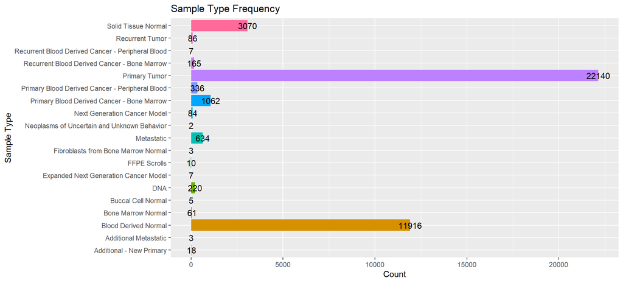

##### Unused Values:

*Benign Neoplasms*, *Blood Derived Cancer - Bone Marrow*, *Blood Derived Cancer - Bone Marrow, Post-treatment*, *Blood Derived Cancer - Peripheral Blood*, *Blood Derived Cancer - Peripheral Blood, Post-treatment*, *Blood Derived Liquid Biopsy*, *Cell Line Derived Xenograft Tissue*, *Cell Lines*, *Control Analyte*, *EBV Immortalized Normal*, *FFPE Recurrent*, *GenomePlex (Rubicon) Amplified DNA*, *Granulocytes*, *Human Tumor Original Cells*, *In Situ Neoplasms*, *Lymphoid Normal*, *Mixed Adherent Suspension*, *Mononuclear Cells from Bone Marrow Normal*, *Next Generation Cancer Model Expanded Under Non-conforming Conditions*, *Not Allowed To Collect*, *Pleural Effusion*, *Post neo-adjuvant therapy*, *Primary Xenograft Tissue*, *Recurrent Blood Derived Cancer - Peripheral Blood Recurrent Tumor*, *Repli-G (Qiagen) DNA*, *Repli-G X (Qiagen) DNA*, *RNA*, *Saliva*, *Slides*, *Total RNA*, *Tumor*, *Tumor Adjacent Normal - Post Neo-adjuvant Therapy*, *Xenograft Tissue*, *Unknown* and *Not Reported*

#### **sample_type_id**

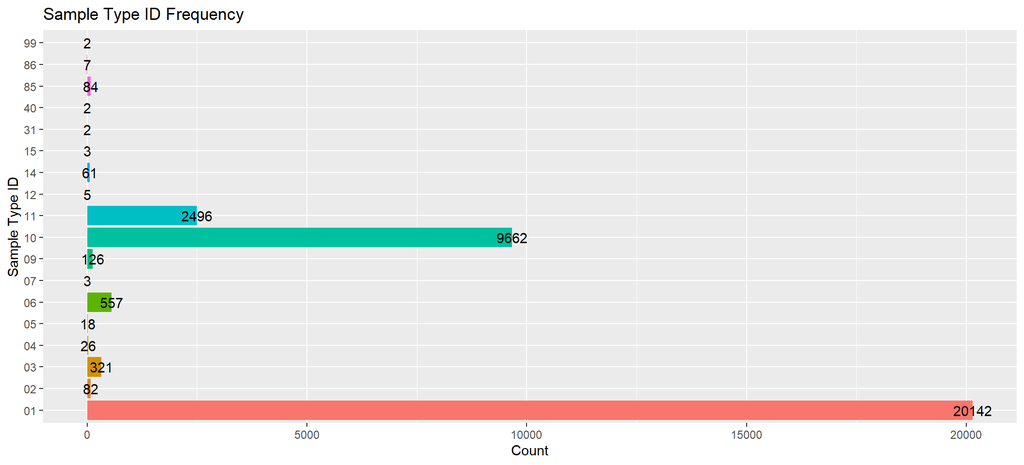

There were 6230 NA entries.

##### Unused Values:

*08*, *13*, *16*, *17*, *18*, *20*, *30*, *32*, *41*, *42*, *50*, *60*, *61* and *87*

#### **Correlation between sample_type and sample_type_id**

Table 3.1a: Correlation between Sample Type and Sample Type ID

| Sample Type ID | Sample Type | Frequency |
| --- | --- | --- |
| 05 | Additional - New Primary | 18 |
| 07 | Additional Metastatic | 3 |
| ’– | Blood Derived Normal | 2253 |
| 10 | Blood Derived Normal | 9662 |
| 99 | Blood Derived Normal | 1 |
| 14 | Bone Marrow Normal | 61 |
| 12 | Buccal Cell Normal | 5 |
| ’– | DNA | 220 |
| 86 | Expanded Next Generation Cancer Model | 7 |
| 01 | FFPE Scrolls | 10 |
| 15 | Fibroblasts from Bone Marrow Normal | 3 |
| ’– | Metastatic | 77 |
| 06 | Metastatic | 557 |
| 31 | Neoplasms of Uncertain and Unknown Behavior | 2 |
| 85 | Next Generation Cancer Model | 84 |
| ’– | Primary Blood Derived Cancer - Bone Marrow | 936 |
| 09 | Primary Blood Derived Cancer - Bone Marrow | 126 |
| ’– | Primary Blood Derived Cancer - Peripheral Blood | 15 |
| 03 | Primary Blood Derived Cancer - Peripheral Blood | 321 |
| ’– | Primary Tumor | 2007 |
| 01 | Primary Tumor | 20132 |
| 99 | Primary Tumor | 1 |
| ’– | Recurrent Blood Derived Cancer - Bone Marrow | 139 |
| 04 | Recurrent Blood Derived Cancer - Bone Marrow | 26 |
| ’– | Recurrent Blood Derived Cancer - Peripheral Blood | 5 |
| 40 | Recurrent Blood Derived Cancer - Peripheral Blood | 2 |
| ’– | Recurrent Tumor | 4 |
| 02 | Recurrent Tumor | 82 |
| ’– | Solid Tissue Normal | 574 |
| 11 | Solid Tissue Normal | 2496 |

##### **Field values without 1:1 Correspondence:**

Table 3.1b: Sample Type and Type ID values without 1:1 correspondence

| Sample Type ID | Sample Type | Frequency |
| --- | --- | --- |
| ’– | Blood Derived Normal | 2253 |
| 10 | Blood Derived Normal | 9662 |
| 99 | Blood Derived Normal | 1 |
| ’– | DNA | 220 |
| 01 | FFPE Scrolls | 10 |
| ’– | Metastatic | 77 |
| 06 | Metastatic | 557 |
| ’– | Primary Blood Derived Cancer - Bone Marrow | 936 |
| 09 | Primary Blood Derived Cancer - Bone Marrow | 126 |
| ’– | Primary Blood Derived Cancer - Peripheral Blood | 15 |
| 03 | Primary Blood Derived Cancer - Peripheral Blood | 321 |
| ’– | Primary Tumor | 2007 |
| 01 | Primary Tumor | 20132 |
| 99 | Primary Tumor | 1 |
| ’– | Recurrent Blood Derived Cancer - Bone Marrow | 139 |
| 04 | Recurrent Blood Derived Cancer - Bone Marrow | 26 |
| ’– | Recurrent Blood Derived Cancer - Peripheral Blood | 5 |
| 40 | Recurrent Blood Derived Cancer - Peripheral Blood | 2 |
| ’– | Recurrent Tumor | 4 |
| 02 | Recurrent Tumor | 82 |
| ’– | Solid Tissue Normal | 574 |
| 11 | Solid Tissue Normal | 2496 |

#### **tissue_type**

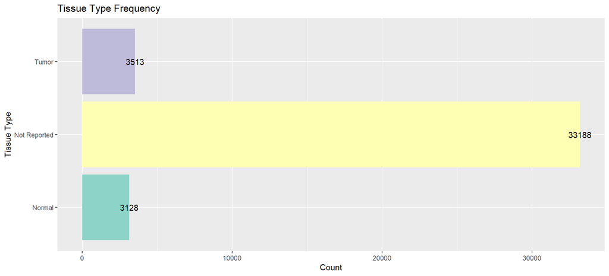

##### Unused Values:

6 Total Values, 3 Unused.

- Abnormal
- Peritumoral
- Unknown

#### **biospecimen_anatomic_site**

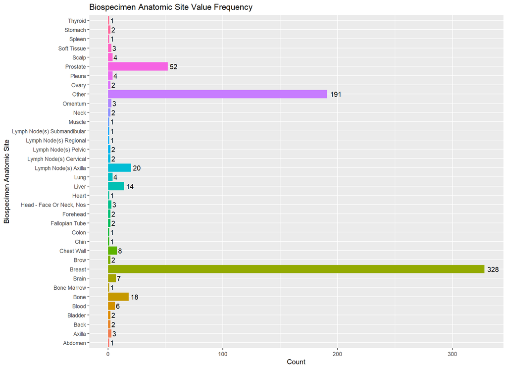

There were 39131 NA entries.

##### Unused Values:

*Abdominal Wall*, *Acetabulum*, *Adenoid*, *Adipose*, *Adrenal*, *Alveolar Ridge*, *Amniotic Fluid*, *Ampulla Of Vater*, *Anal Sphincter*, *Ankle*, *Anorectum*, *Antecubital Fossa*, *Antrum*, *Anus*, *Aorta*, *Aortic Body*, *Appendix*, *Aqueous Fluid*, *Arm*, *Artery*, *Ascending Colon*, *Ascending Colon Hepatic Flexure*, *Auditory Canal*, *Autonomic Nervous System*, *Bile Duct*, *Blood Vessel*, *Bowel*, *Brain Stem*, *Broad Ligament*, *Bronchiole*, *Bronchus*, *Buccal Cavity*, *Buccal Mucosa*, *Buttock*, *Calf*, *Capillary*, *Cardia*, *Carina*, *Carotid Artery*, *Carotid Body*, *Cartilage*, *Cecum*, *Cell-Line*, *Central Nervous System*, *Cerebellum*, *Cerebral Cortex*, *Cerebrospinal Fluid*, *Cerebrum*, *Cervical Spine*, *Cervix*, *Chest*, *Clavicle*, *Clitoris*, *Colon - Mucosa Only*, *Common Duct*, *Conjunctiva*, *Connective Tissue*, *Dermal*, *Descending Colon*, *Diaphragm*, *Duodenum*, *Ear*, *Ear Canal*, *Ear, Pinna (External)*, *Effusion*, *Elbow*, *Endocrine Gland*, *Epididymis*, *Epidural Space*, *Esophageal; Distal*, *Esophageal; Mid*, *Esophageal; Proximal*, *Esophagogastric Junction*, *Esophagus*, *Esophagus - Mucosa Only*, *Eye*, *Femoral Artery*, *Femoral Vein*, *Femur*, *Fibroblasts*, *Fibula*, *Finger*, *Floor Of Mouth*, *Fluid*, *Foot*, *Forearm*, *Foreskin*, *Frontal Cortex*, *Frontal Lobe*, *Fundus Of Stomach*, *Gallbladder*, *Ganglia*, *Gastroesophageal Junction*, *Gastrointestinal Tract*, *Glottis*, *Groin*, *Gum*, *Hand*, *Hard Palate*, *Head & Neck*, *Hepatic*, *Hepatic Duct*, *Hepatic Flexure*, *Hepatic Vein*, *Hip*, *Hippocampus*, *Humerus*, *Hypopharynx*, *Ileum*, *Ilium*, *Index Finger*, *Ischium*, *Islet Cells*, *Jaw*, *Jejunum*, *Joint*, *Kidney*, *Knee*, *Lacrimal Gland*, *Large Bowel*, *Laryngopharynx*, *Larynx*, *Leg*, *Leptomeninges*, *Ligament*, *Lip*, *Lumbar Spine*, *Lymph Node*, *Lymph Node(s) Distant*, *Lymph Node(s) Epitrochlear*, *Lymph Node(s) Femoral*, *Lymph Node(s) Hilar*, *Lymph Node(s) Iliac-Common*, *Lymph Node(s) Iliac-External*, *Lymph Node(s) Inguinal*, *Lymph Node(s) Internal Mammary*, *Lymph Node(s) Mammary*, *Lymph Node(s) Mesenteric*, *Lymph Node(s) Occipital*, *Lymph Node(s) Paraaortic*, *Lymph Node(s) Parotid*, *Lymph Node(s) Popliteal*, *Lymph Node(s) Retroperitoneal*, *Lymph Node(s) Scalene*, *Lymph Node(s) Splenic*, *Lymph Node(s) Subclavicular*, *Lymph Node(s) Supraclavicular*, *Lymph Nodes(s) Mediastinal*, *Mandible*, *Maxilla*, *Mediastinal Soft Tissue*, *Mediastinum*, *Mesentery*, *Mesothelium*, *Middle Finger*, *Mitochondria*, *Nails*, *Nasal Cavity*, *Nasal Soft Tissue*, *Nasopharynx*, *Nerve*, *Nerve(s) Cranial*, *Not Allowed To Collect*, *Occipital Cortex*, *Ocular Orbits*, *Oral Cavity*, *Oral Cavity - Mucosa Only*, *Oropharynx*, *Palate*, *Pancreas*, *Paranasal Sinuses*, *Paraspinal Ganglion*, *Parathyroid*, *Parotid Gland*, *Patella*, *Pelvis*, *Penis*, *Pericardium*, *Periorbital Soft Tissue*, *Peritoneal Cavity*, *Peritoneum*, *Pharynx*, *Pineal*, *Pineal Gland*, *Pituitary Gland*, *Placenta*, *Popliteal Fossa*, *Pylorus*, *Rectosigmoid Junction*, *Rectum*, *Retina*, *Retro-Orbital Region*, *Retroperitoneum*, *Rib*, *Ring Finger*, *Round Ligament*, *Sacrum*, *Salivary Gland*, *Scapula*, *Sciatic Nerve*, *Scrotum*, *Seminal Vesicle*, *Shoulder*, *Sigmoid Colon*, *Sinus*, *Sinus(es), Maxillary*, *Skeletal Muscle*, *Skin*, *Skull*, *Small Bowel*, *Small Bowel - Mucosa Only*, *Small Finger*, *Spinal Column*, *Spinal Cord*, *Splenic Flexure*, *Sternum*, *Stomach - Mucosa Only*, *Subcutaneous Tissue*, *Subglottis*, *Sublingual Gland*, *Submandibular Gland*, *Supraglottis*, *Synovium*, *Temporal Cortex*, *Tendon*, *Testis*, *Thigh*, *Thoracic Spine*, *Thorax*, *Throat*, *Thumb*, *Thymus*, *Tibia*, *Tongue*, *Tonsil*, *Tonsil (Pharyngeal)*, *Trachea / Major Bronchi*, *Transverse Colon*, *Trunk*, *Umbilical Cord*, *Ureter*, *Urethra*, *Urinary Tract*, *Uterus*, *Uvula*, *Vagina*, *Vas Deferens*, *Vein*, *Venous*, *Vertebra*, *Vulva*, *White Blood Cells*, *Wrist*, *Unknown* and *Not Reported*

#### **biospecimen_laterality**

Table 3.3: Biospecimen Laterality Value Distribution

| Biospecimen Laterality | Frequency |
| --- | --- |
| NA | 39829 |

##### Unused Values:

5 total values, all unused.

#### **composition**

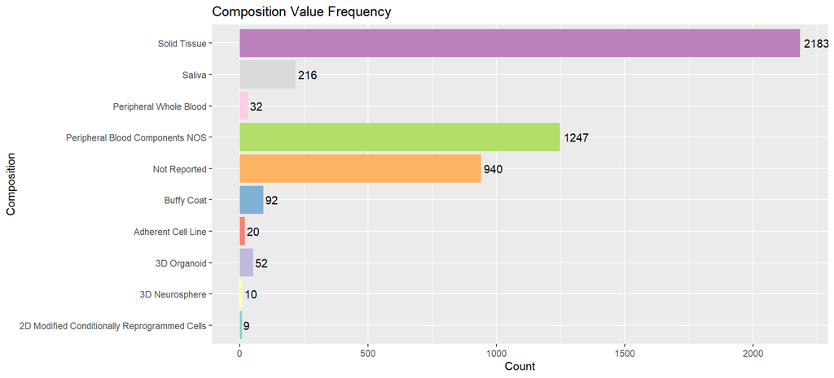

There were 35028 NA entries.

##### Unused Values:

*2D Classical Conditionally Reprogrammed Cells*, *3D Air-Liquid Interface Organoid*, *Bone Marrow Components*, *Bone Marrow Components NOS*, *Buccal Cells*, *Cell*, *Control Analyte*, *Derived Cell Line*, *EBV Immortalized*, *Fibroblasts from Bone Marrow Normal*, *Granulocytes*, *Human Original Cells*, *Liquid Suspension Cell Line*, *Lymphocytes*, *Mixed Adherent Suspension*, *Mononuclear Cells from Bone Marrow Normal*, *Plasma*, *Pleural Effusion*, *Serum*, *Sorted Cells*, *Sputum*, *Whole Bone Marrow* and *Unknown*

#### **diagnosis_pathologically_confirmed**

Table 3.4: Diagnosis Confirmation Distribution

| Diagnosis Pathological Confirmation | Frequency |
| --- | --- |
| NA | 39829 |

##### Unused Values:

4 total values, all unused.

#### **distance_normal_to_tumor**

Table 3.5: distance_normal_to_tumor Distribution

| Distance From Tumor to Normal Tissue | Frequency |
| --- | --- |
| NA | 39829 |

##### Unused Values:

4 total values, all unused.

#### **method_of_sample_procurement**

Table 3.6: Method of Sample Procurement Value Distribution

| Sample Procurement Method | Frequency |
| --- | --- |
| NA | 39829 |

##### Unused Values:

102 total values, all unused.

#### **preservation_method**

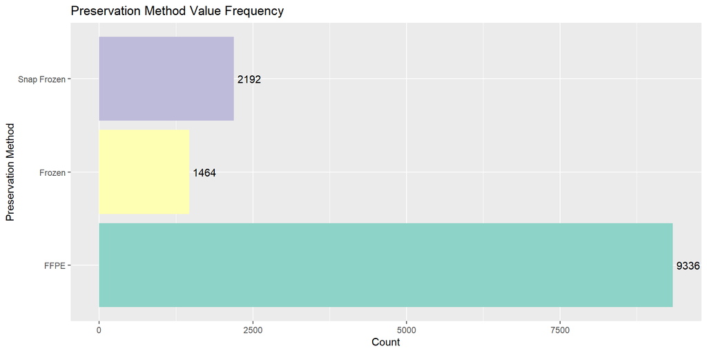

There were 26837 NA entries.

##### Unused Values:

8 total values, 5 unused values listed below.

- Cryopreserved
- Fresh
- OCT
- Unknown
- Not reported

#### **tissue_collection_type**

Table 3.7: Tissue Collection Type Value Distribution

| Tissue Collection Type | Frequency |
| --- | --- |
| NA | 39829 |

##### Unused Values:

2 total values, both unused.

#### **tumor_code**

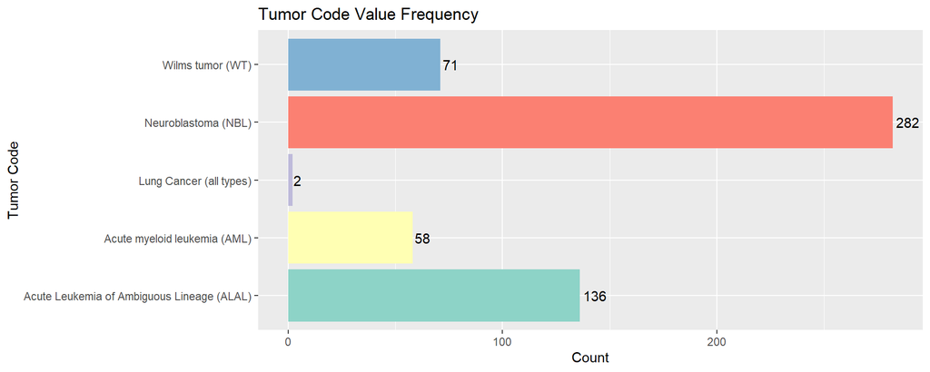

There were 39280 NA entries.

##### Unused Values:

*Acute lymphoblastic leukemia (ALL)*, *Anal Cancer (all types)*, *Cervical Cancer (all types)*, *Clear cell sarcoma of the kidney (CCSK)*, *CNS, ependymoma*, *CNS, glioblastoma (GBM)*, *CNS, low grade glioma (LGG)*, *CNS, medulloblastoma*, *CNS, other*, *CNS, rhabdoid tumor*, *Diffuse Large B-Cell Lymphoma (DLBCL)*, *Ewing sarcoma*, *Induction Failure AML (AML-IF)*, *NHL, anaplastic large cell lymphoma*, *NHL, Burkitt lymphoma (BL)*, *Non cancerous tissue*, *Osteosarcoma (OS)*, *Rhabdoid tumor (kidney) (RT)*, *Rhabdomyosarcoma* and *Soft tissue sarcoma, non-rhabdomyosarcoma*

#### **tumor_code_id**

Table 3.8: Tumor Code ID Value Distribution

| Tumor Code ID | Frequency |
| --- | --- |
| NA | 39282 |
| 15 | 136 |
| 20 | 58 |
| 30 | 282 |
| 50 | 71 |

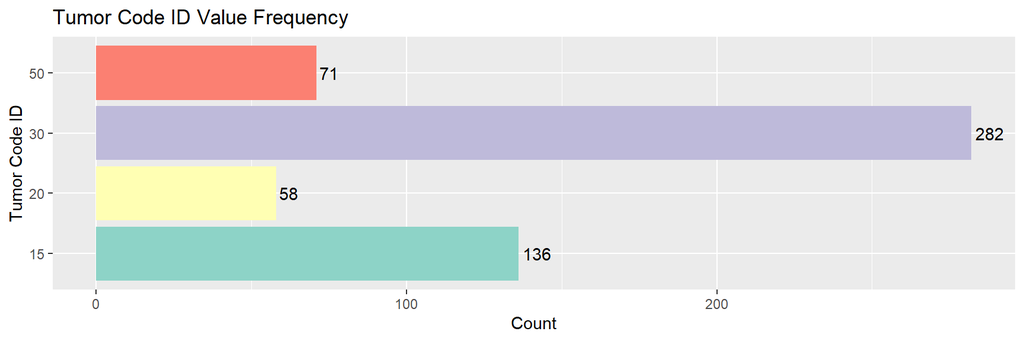

There were 39282 NA entries.

##### Unused Values:

*00*, *01*, *02*, *03*, *04*, *10*, *21*, *40*, *41*, *51*, *52*, *60*, *61*, *62*, *63*, *64*, *65*, *70*, *71*, *80* and *81*

#### **correlation between tumor_code and tumor_code_id**

Table 3.9a: Correlation between Tumor Code and Tumor Code ID

| Tumor Code ID | Tumor Code | Frequency |
| --- | --- | --- |
| 15 | Acute Leukemia of Ambiguous Lineage (ALAL) | 136 |
| 20 | Acute myeloid leukemia (AML) | 58 |
| ’– | Lung Cancer (all types) | 2 |
| 30 | Neuroblastoma (NBL) | 282 |
| 50 | Wilms tumor (WT) | 71 |

##### **Field values without 1:1 Correspondence:**

Table 3.9b: Tumor Code and Code ID values without 1:1 correspondence

| Tumor Code ID | Tumor Code | Frequency |
| --- | --- | --- |
| ’– | Lung Cancer (all types) | 2 |

#### **tumor_descriptor**

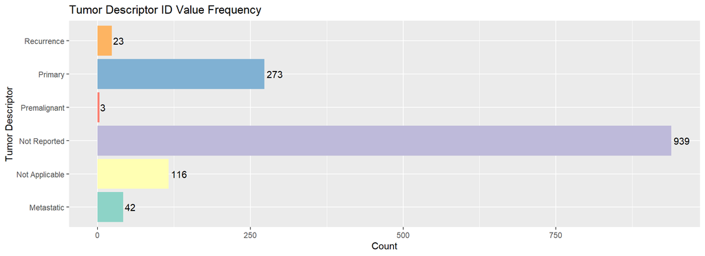

There were 38433 NA entries.

##### Unused Values:

9 total values, 3 unused listed below:

- NOS
- Xenograft
- Unknown